# Der verzauberte Würfel

## Prolog

In unserer modernen Welt haben wir Magie und Mythen hinter uns gelassen und bauen stattdessen auf Fakten und Daten. Wir haben Frieden mit dem Zufall geschlossen und akzeptieren zum Beispiel, dass wir einen Würfel nicht beeinflussen können - es sei denn, er ist gezinkt. Aber was, wenn es einen Weg gäbe, den Zufall durch Magie zu beeinflussen? Wenn wir unsere magischen Kräfte schlichtweg vergessen hätten? Was, wenn wir jedes Brettspiel gewinnen könnten, wenn wir nur unsere schlummernden magischen Weisheiten wiederentdecken?

Und was, wenn gerade deine magischen Fähigkeiten ans Licht gekommen wären, und dann ein Klugscheißer vorbei kommt und dir was von Regression zur Mitte erzählt?

## Worum es hier geht

Ich werde mit meinen “magischen Kräfte” einen Würfel verzaubern, um seine “Performance” zu verbessern. Ich kann nämlich Würfel magisch beeinflussen - legt euch besser nicht mit mir bei Mensch-ärgere-dich-nicht an! Dabei zeige ich euch den `R`-Code, den ich verwende, um meine magischen Würfeldaten zu analysieren - und um bei Bedarf welche zu generieren. Spoiler-Alarm: Letztendlich werde ich euch zeigen, dass Magie in Wahrheit doch nicht funktioniert. Sorry.

## Daten einlesen und aufbereiten

Ich habe tatsächlich allen Ernstes 200 mal einen Würfel gewürfelt, und immer dann, wenn er eine 1 oder eine 2 gezeigt hat, habe ich ihn “verzaubert”, um ihm ein bisschen auf die Sprünge zu helfen. Glaubt ihr nicht? [In diesem Video](https://www.youtube.com/watch?v=LB_X3jXZC8I) gibt es den Beweis. Der Datensatz ist in diesem Repo hochgeladen, wir können ihn also einfach einlesen.

```r
# Verwendete packages
# Datenverarbeitung
library(tidyverse)
library(effsize)
library(prmisc)
# Generierung der html Datei
library(kableExtra)

# Theme für die Plots
julis_theme <-
  theme(panel.background = element_blank(),
        panel.grid = element_blank(),
        axis.line = element_line(colour = "black"),
        axis.title.x = element_blank(),
        axis.ticks.x = element_blank(),
        legend.position = "none",
        plot.title = element_text(size = 14, face = "plain", hjust = .5),
        axis.text = element_text(size = 12),
        strip.text = element_text(size = 12))

## Wuerfel-Daten laden
ww <-
  read.csv("enchanted_die.csv", sep = ";")
```

Kurze Inspektion der Daten: Es gibt eine Spalte namens `roll`, in der festgehalten wird, welche Zahl gewürfelt wurde. Und dann eine Spalte `magic_before`, die kodiert, ob vor dem jeweiligen Wurf “Magie stattgefunden hat”. Eine 1 bedeutet, dass vor dem Wurf gezaubert wurde, eine 0 bedeutet, das nicht gezaubert wurde.

```r
head(ww, 10) %>%
  kable() %>%
  kable_styling("striped")
```

| roll | magic_before |
| --- | --- |
| 3 | 0 |
| 2 | 0 |
| 5 | 1 |
| 6 | 0 |
| 1 | 0 |
| 4 | 1 |
| 5 | 0 |
| 3 | 0 |
| 5 | 0 |
| 6 | 0 |

Wird der Wurf nach der Intervention besser? Das finden wir heraus, indem wir die Differenz zum vorherigen Wurf berechnen. Für den ersten Wurf fügen wir einen fehlenden Wert ein, denn da es keinen Wurf vor dem ersten Wurf gibt, gibt es auch keine Differenz.

```r
ww$diff <- c(NA, diff(ww$roll))
head(ww, 10) %>%
  kable() %>%
  kable_styling("striped")
```

| roll | magic_before | diff |
| --- | --- | --- |
| 3 | 0 | NA |
| 2 | 0 | -1 |
| 5 | 1 | 3 |
| 6 | 0 | 1 |
| 1 | 0 | -5 |
| 4 | 1 | 3 |
| 5 | 0 | 1 |
| 3 | 0 | -2 |
| 5 | 0 | 2 |
| 6 | 0 | 1 |

## Ergebnisse

Ein kurzer Überblick, wie die mittlere Differenz für Würfe mit vs. ohne Magie aussieht:

```r
by(ww$diff, ww$magic_before, summary)
```

```
## ww$magic_before: 0
##    Min. 1st Qu.  Median    Mean 3rd Qu.    Max.    NA's
## -5.0000 -2.0000 -1.0000 -0.9071  1.0000  3.0000       1
## ------------------------------------------------------------
## ww$magic_before: 1
##    Min. 1st Qu.  Median    Mean 3rd Qu.    Max.
##  -1.000   1.000   2.000   2.119   3.500   5.000
```

Bereits auf den ersten Blick sieht es so aus, als würde sich der Würfel verbessern, wenn vorher gezaubert wurde - und zwar im Mittel um 2.119 Punkte. Dagegen verschlechtert er sich sogar, wenn man vorher nicht zaubert! Die Punktzahl nimmt dann im Schnitt um 0.9071 Punkte ab. Um es mal grafisch darzustellen: Die Punkte sind einzelne Differenzen von Wurf zu Wurf, also z.B. könnte ein einzelner Punkt einen Wurf repräsentieren, bei dem die Differenz zum vorherigen Wurf 2 beträgt und bei dem zuvor gezaubert wurde. Das dicke Viereck in der Mitte ist der Mittelwert, und die horizontale Linie liegt bei 0. Immer, wenn ein Punkt auf dieser Linie liegt, hat der Würfel sich also weder “verbessert” noch verschlechtert.

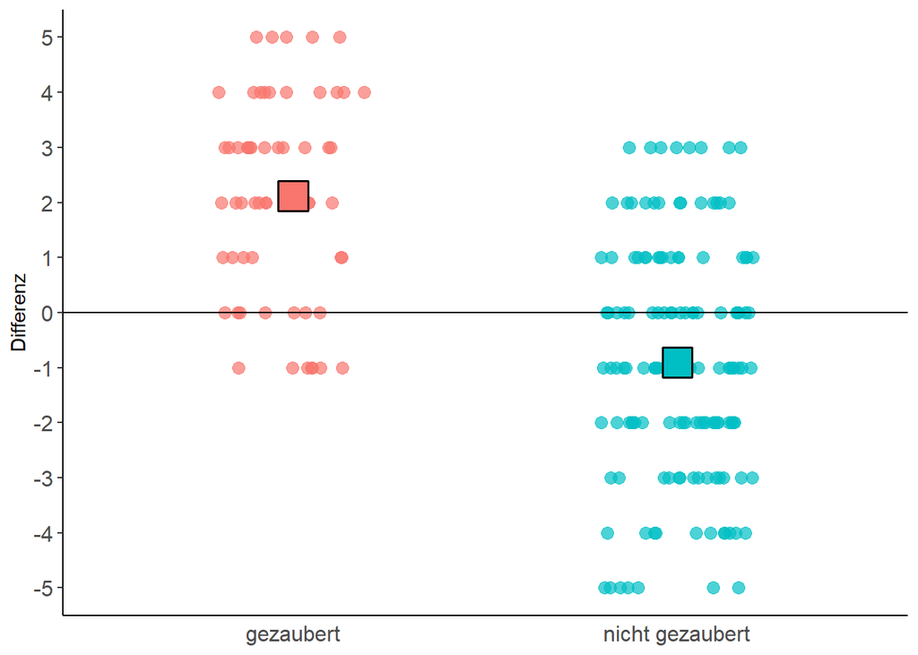

```r
ww %>%
  mutate(magic_before = ifelse(magic_before == 0, "nicht gezaubert", "gezaubert")) %>%
  ggplot(aes(x = factor(magic_before), y = diff, colour = factor(magic_before),
             fill = factor(magic_before))) +
  geom_point(position = position_jitter(width = .2, height = 0), alpha = .7, size = 3) +
  stat_summary(size = 2, fun = "mean", shape = 22, colour = "black") +
  geom_hline(yintercept = 0) +
  labs(y = "Differenz", x = "vorher gezaubert") +
  scale_y_continuous(breaks = seq(-5, 5, 1)) +
  julis_theme
```

Wir können das natürlich auch statistisch auswerten: Wenn wir mit einem t-Test vergleichen, ob der Würfel mit Magie statistisch signifikant besser abschneidet als ohne Magie, dann lautet die klare Antwort: Ja!

```r
# t-Test zum Vergleich der Differenz zum nächsten Wurf mit oder ohne Magie
(wuerfel_ttest <- t.test(ww$diff ~ ww$magic_before))
```

```
##
##  Welch Two Sample t-test
##
## data:  ww$diff by ww$magic_before
## t = -10.154, df = 125.35, p-value < 2.2e-16
## alternative hypothesis: true difference in means is not equal to 0
## 95 percent confidence interval:
##  -3.615525 -2.436048
## sample estimates:
## mean in group 0 mean in group 1
##      -0.9071429       2.1186441
```

```r
# Effektstaerke
(wuerfel_effsize <- cohen.d(ww$diff ~ ww$magic_before))
```

```
##
## Cohen's d
##
## d estimate: -1.484926 (large)
## 95 percent confidence interval:
##     lower     upper
## -1.824400 -1.145452
```

Der Würfel ist ganz klar besser, wenn vorher gezaubert wurde, $t(125.35) = -10.15$, $p < .001$, $d = -1.48$. Und die Effektgröße ist riesig! Die standardisierte Effektgröße $d$ nutzen wir, um den Unterschied zwischen zwei Gruppen (hier: mit vs. ohne Magie) relativ zur Streuung der Daten auszudrücken. Man kann sich vorstellen, dass z.B. ein Unterschied von 1 bei einem Würfel, der Zahlen zwischen 1 und 20 würfelt (es ist ein D&D-Würfel), nicht so krass ist wie ein Unterschied von 1 bei einem Würfel, der Zahlen von 1 bis 6 würfelt. Es ist schwierig, ein intuitives Gefühl für Effektgrößen zu geben, wenn man noch nie davon gehört hat, aber man kann es in etwa so ausdrücken: ForscherInnen in der Psychologie und den Neurowissenschaften würden bei so einer Effektgröße hinten über fallen.

## Was erklärt das Ergebnis?

Die meisten haben sich vermutlich schon gedacht, dass das Ergebnis nicht durch Magie erklärt werden kann. Aber ist mein Würfel womöglich gezinkt? Sieht nicht so aus: Die Würfe sind ziemlich gleichverteilt. Wer findet, dass das nicht gleichmäßig genug aussieht, der kann anhand der zufällig computer-generierten Würfeldaten mal vergleichen, wie Zufall üblicherweise “aussieht”.

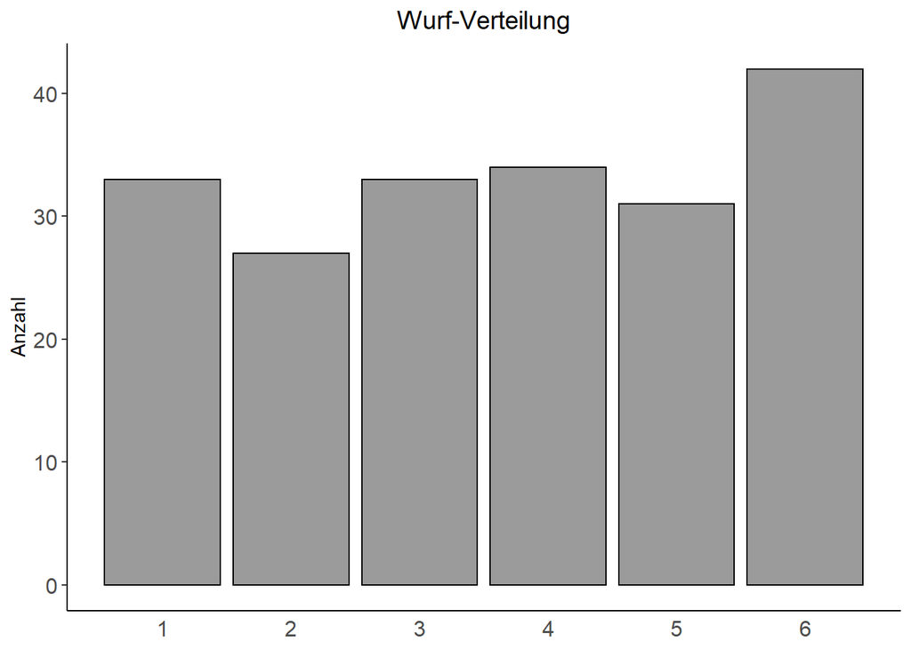

```r
ww %>%
  ggplot(aes(x = roll)) +
  geom_bar(col = "black", alpha = .6) +
  scale_x_continuous(breaks = seq(1, 6, 1)) +
  labs(title = "Wurf-Verteilung", x = "Augenzahl", y = "Anzahl") +
  julis_theme
```

Aber: Kommen die Zahlen denn jeweils mit oder ohne Magie gleich häufig vor? Hier sieht man, dass die Augenzahlen mit vs. ohne Magie wieder relativ gleichmäßig verteilt sind, aber noch etwas anderes fällt auf: Es gibt viel mehr Würfe, in denen vorher nicht gezaubert wurde.

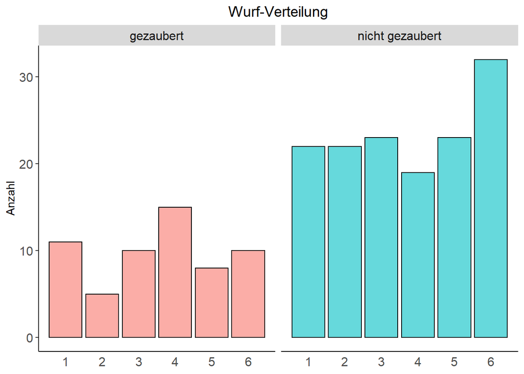

```r
ww %>%
  mutate(magic_before = ifelse(magic_before == 0, "nicht gezaubert", "gezaubert")) %>%
  ggplot(aes(x = roll, fill = magic_before)) +
  geom_bar(col = "black", alpha = .6) +
  scale_x_continuous(breaks = seq(1, 6, 1)) +
  labs(title = "Wurf-Verteilung", x = "Augenzahl", y = "Anzahl") +
  facet_wrap(~magic_before) +
  julis_theme
```

## Regression zur Mitte

Das liegt aber nicht daran, *dass* ich gezaubert habe, sondern *wann* ich gzeaubert habe. Das Phänomen ist als Regression zur Mitte bekannt: Ergebnisse werden sozusagen “zur Mitte hingezogen”, das heißt, nach sehr guten Leistungen folgt meistens eine schlechtere und umgekehrt. Das Phänomen kennen wir aus dem Sport oder auch aus dem Alltag, wenn wir sagen “Schlimmer kann’s ja nicht mehr werden”. Wir haben also im Alltag ein ganz intuitives Verständnis für die Regression zur Mitte, aber leider nicht immer. Sportler werden zur Schnecke gemacht, wenn sie ihre Glanzleistung aus dem vorherigen Wettkampft nicht wiederholen können. Wir wundern uns, dass die Fortsetzung eines Films nicht an den ersten Teil anknüpfen kann. Oder wir nehmen genau dann Globuli, wenn es uns gerade am dreckigsten geht - und machen dann die Globuli dafür verwantwortlich, dass es besser geworden ist.

## Computergenerierte Daten

Um noch mal zu veranschaulichen, Wie beliebig das Phänomen ist, hier eine Funktion, die “verzauberte” Würfelwürfe generiert. Die Funktion generiert eine Anzahl von zufälligen Würfen (angegeben über `nrolls`) und “verzaubert” bestimmte Augenzahlen. Das heißt, über `magic_numbers` geben wir an, nach welchen Augenzahlen gezaubert werden soll. Für die D&Dler unter euch ist es über `die_outcomes` auch möglich anzugeben, welche Augenzahlen möglich sein können, also z.B. 1-20 anstatt 1-6.

```r
enchant_die <- function(nrolls, magic_numbers = c(1, 2), die_outcomes = 1:6) {

  # Wenn mindestens eine "verzauberte Zahl" nicht in den möglichen Würfelzahlen vorkommt,
  # gib eine Fehlermeldung aus.
  if (sum(!magic_numbers %in% die_outcomes) > 0) {
    stop("Woopsie! Du willst mindestens eine Augenzahl verzaubern, die nicht in den möglichen Augenzahlen des Würfels vorkommt!")
  }

  dd <- data.frame(roll = sample(die_outcomes, nrolls, replace = TRUE),
                   magic_before = NA)

  # Wenn die zuvor gewürfelte Zahl zu den "magic numbers" gehört, "verzaubere" sie.
  # Im ersten Wurf hat vorher allerdings keine Magie stattgefunden (fehlender Wert)
  dd$magic_before <- ifelse(lag(dd$roll) %in% magic_numbers, 1, 0)

  # Im ersten Wurf hat allerdings keine Magie stattgefunden.
  dd$magic_before[1] <- 0

  # Sende eine magische Nachricht, wenn die Funktion fertig ist.
  magic_message <- c("Missetat begangen", "Magisch!", "Die Würfel sind gefallen",
                     "Du bist ein Zauberer, Harry!",
                     "Magie liegt in der Luft!", "Huch, hast du das gefühlt?", "Bezaubernd!",
                     "Danke für ihre Reise mit Enchanted Dies!", "Ich bin völlig verhext.",
                     "Aus großer Kraft folgt große Verantwortung", "Das sind eine Menge Würfelwürfe.",
                     "6 ist meine Glückszahl!")

  print(sample(magic_message, 1))

  return(dd)
}
```

Wieso nicht mal 500 Würfe generieren, aber nur dann zaubern, wenn vorher eine 5 oder eine 6 geworfen wurden?

```r
ww <- enchant_die(500, magic_numbers = c(5, 6))
```

```
## [1] "Bezaubernd!"
```

Hier einmal fix die statistiken und die Plots, die wir auch zuvor für die echten Daten generiert haben. Wie wir sehen, ist nun plötzlich der Würfel ohne Zauberei besser - weil wir dieses Mal die hohen Zahlen verzaubert haben. Das ist ein bisschen, als würde man eine Kopfschmerztablette geben, wenn es einem gerade blendend geht. Es ist nicht möglich, dass die Kopfschmerzen danach besser werden - man hat ja keine - aber es kann schon sein, dass man danach zufällig Kopfschmerzen bekommt.

```
## ww$magic_before: 0
##    Min. 1st Qu.  Median    Mean 3rd Qu.    Max.    NA's
## -3.0000 -1.0000  1.0000  0.9318  3.0000  5.0000       1
## ------------------------------------------------------------
## ww$magic_before: 1
##    Min. 1st Qu.  Median    Mean 3rd Qu.    Max.
##  -5.000  -4.000  -2.000  -1.938   0.000   1.000
```

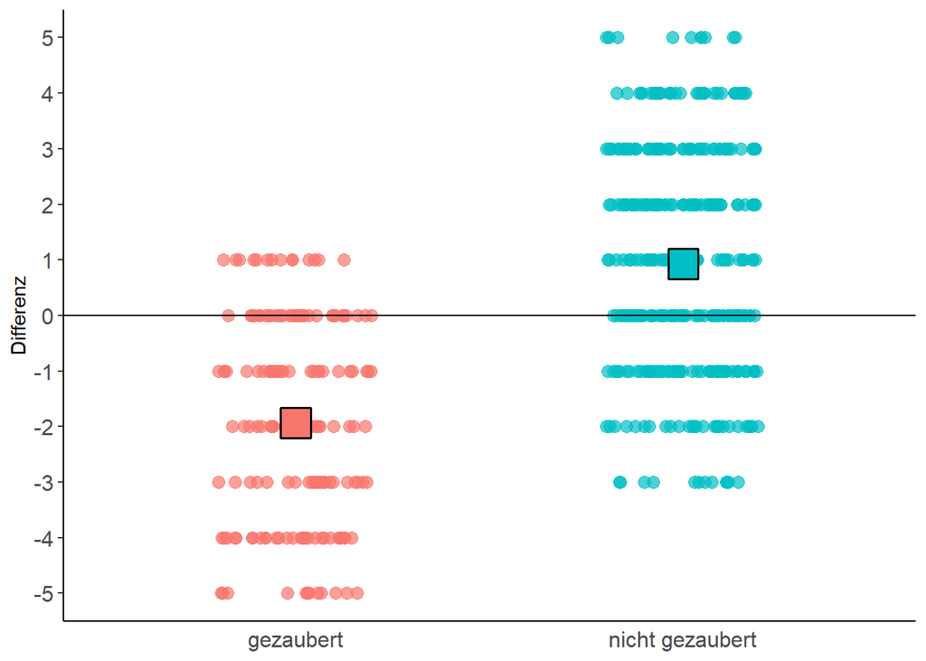

```
##
##  Welch Two Sample t-test
##
## data:  ww$diff by ww$magic_before
## t = 15.898, df = 351.44, p-value < 2.2e-16
## alternative hypothesis: true difference in means is not equal to 0
## 95 percent confidence interval:
##  2.514967 3.225078
## sample estimates:
## mean in group 0 mean in group 1
##       0.9317507      -1.9382716
```

```
##
## Cohen's d
##
## d estimate: 1.462178 (large)
## 95 percent confidence interval:
##    lower    upper
## 1.253485 1.670872
```

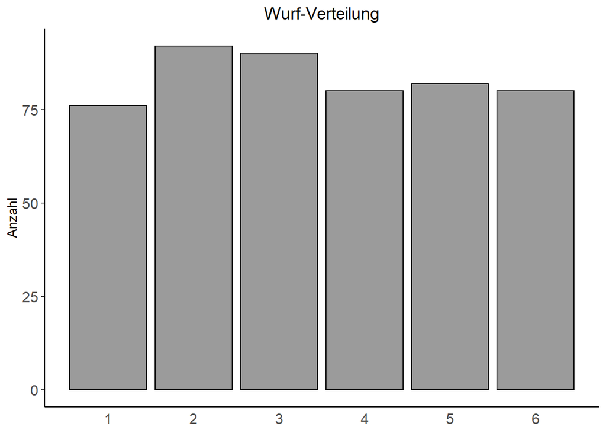

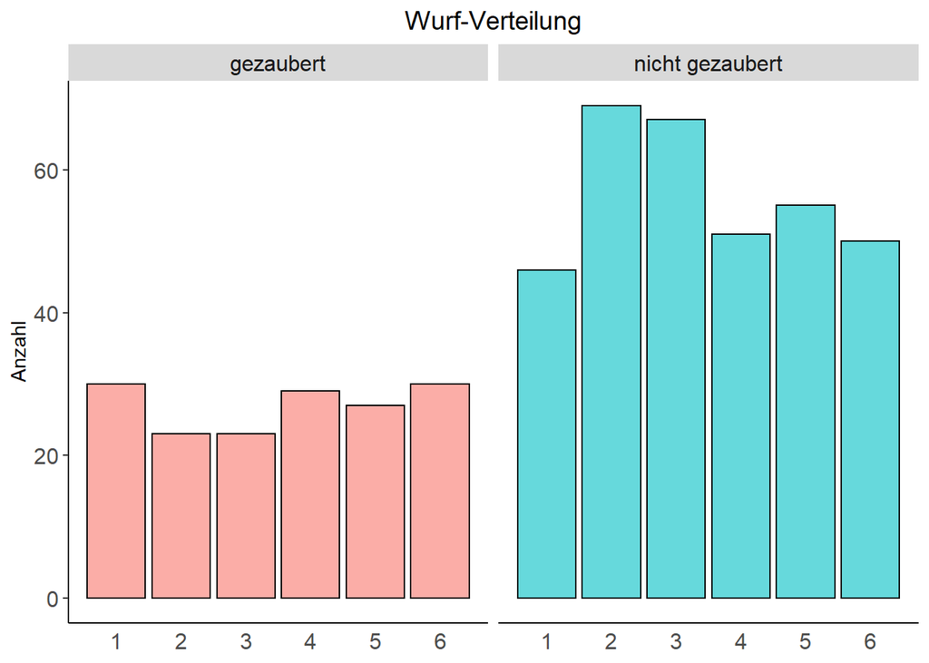